# ARIMA Model for Unemployment Rate

During exploratory data analysis (EDA), it was observed that the raw data is often non-stationary, exhibiting trends, seasonality, and other complex patterns that can make modeling and forecasting difficult. To address this issue, the data is often differentiated to achieve stationarity, which is a key assumption of the ARIMA model.

Differencing involves calculating the difference between each data point and the previous data point, which can help to remove trends and seasonality from the data. The goal is to create a new series of data that is stationary, meaning that the statistical properties of the data do not change over time.

#### Differentiated Time Series Plot

**Plot**

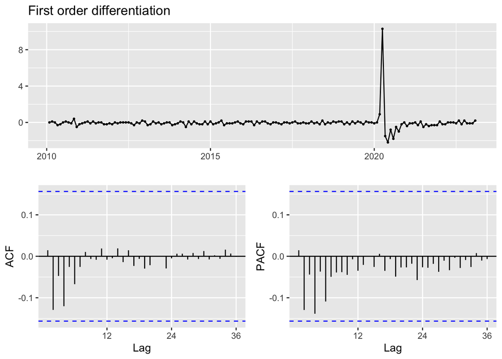

```r
#import the data
df <- read.csv("DATA/CLEANED DATA/unemployment_rate_clean_data.csv")
#convert the data to ts data
myts<-ts(df$Value,frequency=12,start=c(2010/1/1))
#First order differentiation
df1 <- diff(myts)
# Plot
myts  %>% diff() %>% ggtsdisplay(main = "First order differentiation")
```

**ACF**

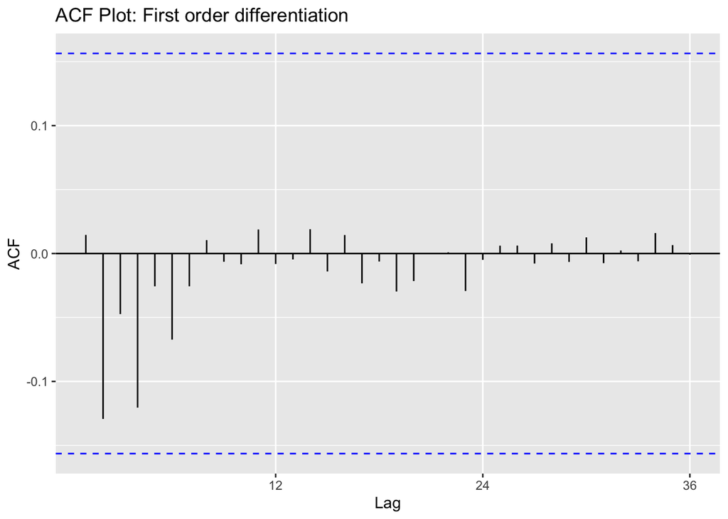

```r
#ACF plot
ggAcf(df1,36,main="ACF Plot: First order differentiation")
```

**PACF**

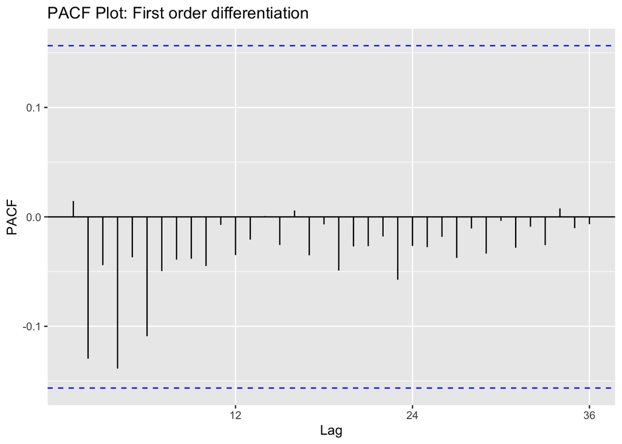

```r
ggPacf(df1,36,main="PACF Plot: First order differentiation")
```

**ADF Test**

```r
tseries::adf.test(df1)
```

```
    Augmented Dickey-Fuller Test

data:  df1
Dickey-Fuller = -6.457, Lag order = 5, p-value = 0.01
alternative hypothesis: stationary
```

After analyzing the ACF and PACF plots, it can be observed that most of the bar lines lie between the blue lines, indicating that the time series is stationary. This has been further confirmed through an Augmented Dickey-Fuller test as the p-value is less than 0.05. Once the data is stationary, the next step is to model it using ARIMA. The combination of ACF and PACF plots can help determine the appropriate values for p, d, and q in the ARIMA model. The order of differencing required to achieve stationarity gives the d value. The p value is determined by examining significant spikes at various lags in the PACF plot, while the q value is determined through significant spikes in the ACF plot. It is important to consider other methods such as grid search and information criteria to ensure the most appropriate model is selected.

Here the parameters are d = 1 p = 0 (PACF Plot) q = 0 (ACF Plot)

#### Model Selection

**ARIMA Result**

```r
model <- arima(myts,c(0,1,0))
model
```

```
Call:
arima(x = myts, order = c(0, 1, 0))


sigma^2 estimated as 0.7845:  log likelihood = -203.72,  aic = 409.43
```

**Auto Arima Model**

```r
auto.arima(myts)
```

```
Series: myts
ARIMA(0,1,0)

sigma^2 = 0.7845:  log likelihood = -203.72
AIC=409.43   AICc=409.46   BIC=412.49
```

#### Model Diagnostic

**Model Plot**

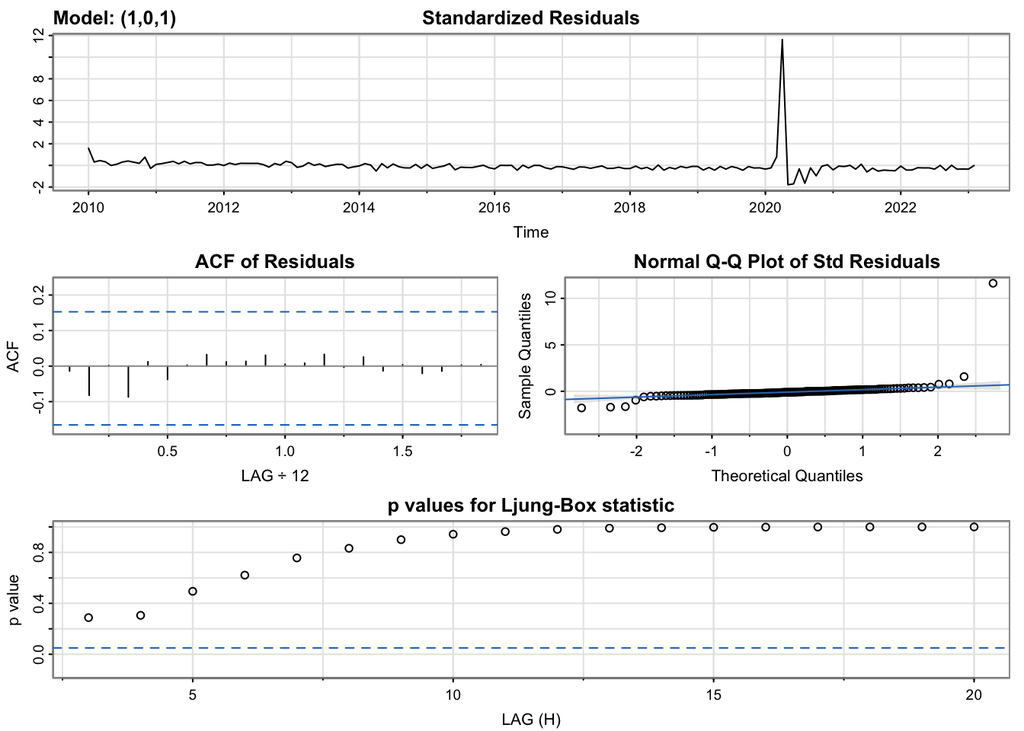

```r
model_output <- capture.output(sarima(myts, 1,0,1))
```

**Model 1**

```r
cat(model_output[62:93], model_output[length(model_output)], sep = "\n")
```

```
$fit

Call:
arima(x = xdata, order = c(p, d, q), seasonal = list(order = c(P, D, Q), period = S),
    xreg = xmean, include.mean = FALSE, transform.pars = trans, fixed = fixed,
    optim.control = list(trace = trc, REPORT = 1, reltol = tol))

Coefficients:
         ar1     ma1   xmean
      0.9156  0.0771  6.1460
s.e.  0.0355  0.0950  0.8277

sigma^2 estimated as 0.7549:  log likelihood = -202.96,  aic = 413.93

$degrees_of_freedom
[1] 155

$ttable
      Estimate     SE t.value p.value
ar1     0.9156 0.0355 25.7721  0.0000
ma1     0.0771 0.0950  0.8118  0.4182
xmean   6.1460 0.8277  7.4254  0.0000

$AIC
[1] 2.619783

$AICc
[1] 2.620769

$BIC
[1] 2.697317
```

**Residual**

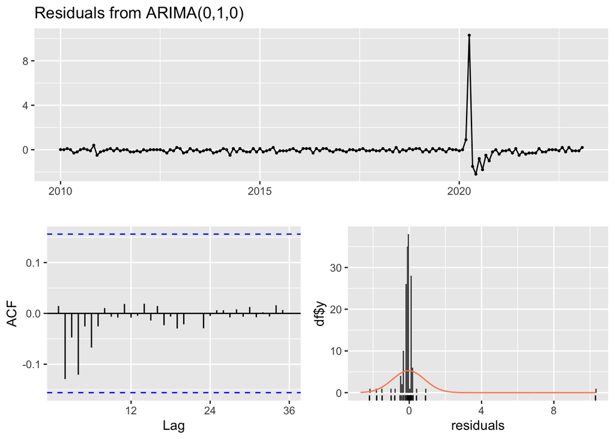

```
    Ljung-Box test

data:  Residuals from ARIMA(0,1,0)
Q* = 7.2289, df = 24, p-value = 0.9996

Model df: 0.   Total lags used: 24
```

```r
arima <- auto.arima(myts)
checkresiduals(arima)
```

#### Forcast

**Short Term Forcast**

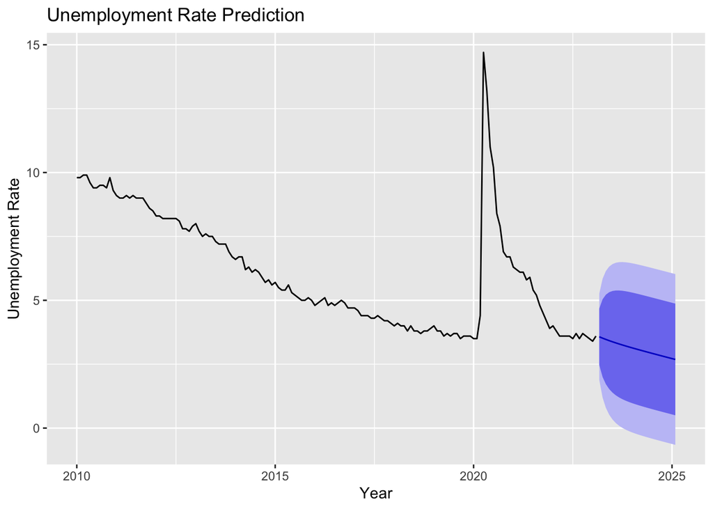

```r
myts %>%
  Arima(order=c(1,0,1),include.drift = TRUE) %>%
  forecast %>%
  autoplot(main = "Unemployment Rate Prediction") +
  ylab("Unemployment Rate") + xlab("Year")
```

**Long term Forcast**

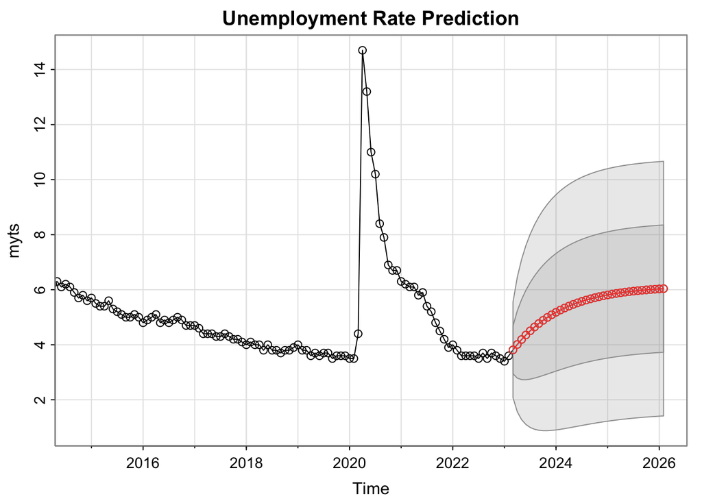

```
$pred
          Jan      Feb      Mar      Apr      May      Jun      Jul      Aug
2023                   3.814151 4.010889 4.191028 4.355968 4.506993 4.645275
2024 5.180167 5.261654 5.336266 5.404583 5.467136 5.524412 5.576855 5.624873
2025 5.810614 5.838911 5.864819 5.888542 5.910264 5.930153 5.948364 5.965038
2026 6.029536 6.039362
          Sep      Oct      Nov      Dec
2023 4.771891 4.887824 4.993976 5.091172
2024 5.668841 5.709098 5.745959 5.779711
2025 5.980306 5.994285 6.007085 6.018805
2026

$se
           Jan       Feb       Mar       Apr       May       Jun       Jul
2023                     0.8688527 1.2243105 1.4569544 1.6265546 1.7561668
2024 2.1374499 2.1671027 2.1916538 2.2120269 2.2289639 2.2430649 2.2548189
2025 2.2941710 2.2975230 2.3003295 2.3026798 2.3046483 2.3062974 2.3076791
2026 2.3123513 2.3127525
           Aug       Sep       Oct       Nov       Dec
2023 1.8578756 1.9390393 2.0045542 2.0578738 2.1015336
2024 2.2646262 2.2728158 2.2796591 2.2853807 2.2901664
2025 2.3088368 2.3098070 2.3106200 2.3113014 2.3118726
2026
```

```r
sarima.for(myts,36, 1,0,1, main = "Unemployment Rate Prediction")
```

The two figures above show an idea of the short term and the long-term forecasted unemployment rate. The forecasted values is be based on the estimated parameters of the model, which were obtained by fitting it to the historical data. One way to assess the accuracy of the forecasts is to use cross-validation, which involves splitting the data into training and testing sets and comparing the predicted values to the actual values in the test set. This can help to identify any potential problems with the model and to fine-tune the model parameters.

**12 Step ahead Cross Validation**

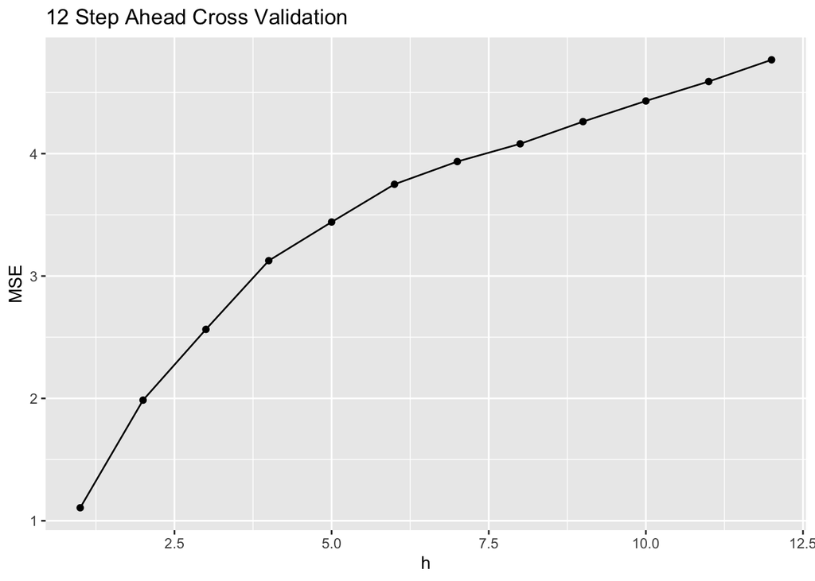

```r
#a seasonal cross validation using 12 steps ahead forecasts
farima1 <- function(x, h){forecast(Arima(x, order=c(1,0,1)), h=h)}

# Compute cross-validated errors for up to 12 steps ahead
e <- tsCV(myts, forecastfunction = farima1, h = 12)

# Compute the MSE values and remove missing values
mse <- colMeans(e^2, na.rm = TRUE)

# Plot the MSE values against the forecast horizon
data.frame(h = 1:12, MSE = mse) %>%
  ggplot(aes(x = h, y = MSE)) + geom_point()+geom_line()+ggtitle("12 Step Ahead Cross Validation")
```

**1 Step ahead Cross Validation**

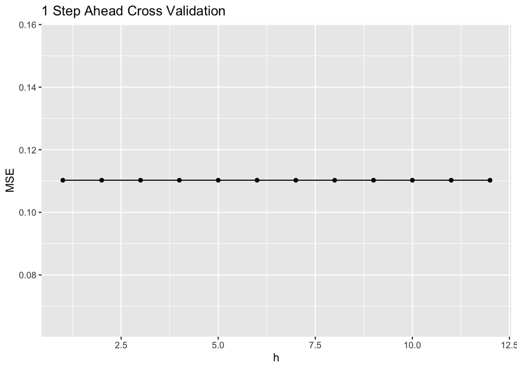

```r
#a seasonal cross validation using 1 steps ahead forecasts
farima1 <- function(x, h){forecast(Arima(x, order=c(1,0,1)),h=h)}

# Compute cross-validated errors for up to 1 steps ahead
e <- tsCV(myts, forecastfunction = farima1, h = 1)
mse <-abs(mean(e,na.rm=TRUE))

# Plot the MSE values against the forecast horizon
data.frame(h = 1:12, MSE = mse) %>%
  ggplot(aes(x = h, y = MSE)) + geom_point()+geom_line()+ggtitle("1 Step Ahead Cross Validation")
```

The one-step-ahead forecasting plot shows that the MSE seems to be stable. The MSE is tend to rise by 12 steps at each step of cross-validation. Lastly, the above-mentioned ARIMA model should be compared to benchmark methods before being used for a long time.

#### Model Comparison

**Plot**

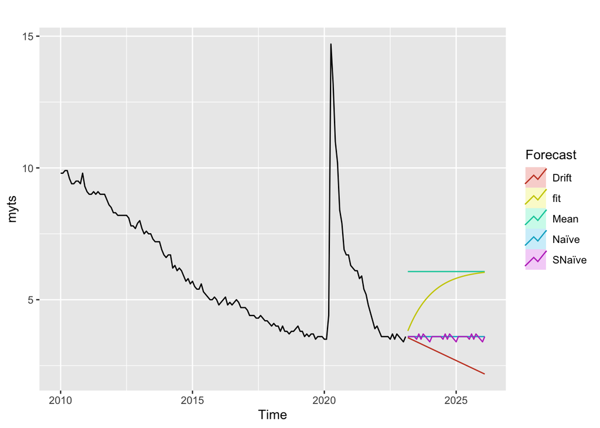

```r
fit <- Arima(myts, order=c(1,0,1))
autoplot(myts) +
  autolayer(meanf(myts, h=36),
            series="Mean", PI=FALSE) +
  autolayer(naive(myts, h=36),
            series="Naïve", PI=FALSE) +
  autolayer(snaive(myts, h=36),
            series="SNaïve", PI=FALSE)+
  autolayer(rwf(myts, h=36, drift=TRUE),
            series="Drift", PI=FALSE)+
  autolayer(forecast(fit,36),
            series="fit",PI=FALSE) +
  guides(colour=guide_legend(title="Forecast"))
```

**Model Error Table**

```r
summary <- summary(fit)
snaive <- snaive(myts, h=36)
#accuracy(snaive)
```

| Error | Model | Snavie |
| --- | --- | --- |
| ME | -0.03281026 | 0.4958904 |
| RMSE | 0.8688527 | 2.221162 |
| MAE | 0.2861976 | 1.330137 |
| MPE | -1.977255 | -13.26146 |
| MAPE | 4.412742 | 22.30239 |
| MASE | 0.215164 | 1.0000000 |
| ACF1 | -0.0139776 | 0.819433 |